# P6 Linear Regression for Binary, Continuous and Event-Time Outcomes

Dominik Frei

16.06.2022

# 1 Overview

## 1.1 Abstract

The aim of this work was to get some intuition about linear regression. Three different data sets where used (titanic, mtcars, lung) and different types of data where used as dependent variable:  
- Titanic: Survival (Binary)  
- mtcars: mpg (Miles per Gallon; Continuous)  
- lung: Survival(-time) (Time-Event Data)

Simple regression models where fit using different data types (binary, categorical, continuous) as independent variables. The results where interpreted and the model assumptions where checked.  
Then multiple linear regression models where fit, using combinations of the independent variables used to fit the simple regression models. It was assessed if there is confounding or effect modification between the independent variables. Here too, the results where interpreted and the model assumptions where checked.

Finally, in the cases where more independent variables where available, the best model was searched for.

## 1.2 Resources

Sources of data sets used:  
- Titanic: http://math.ucdenver.edu/RTutorial/titanic.txt  
- mtcars: https://r-data.pmagunia.com/dataset/mtcars  
- lung: https://r-data.pmagunia.com/dataset/r-dataset-package-survival-lung

## 1.3 What I learned

- (Multiple) Linear Regression: Fitting models, interpreting their results, assessing if there is significant confounding or effect modification, check the model assumptions
- (Multiple) Logistic Regression: Fitting models, interpreting their results, assessing if there is significant confounding or effect modification, check the model assumptions
- (Multiple) Cox Regression: Fitting models, interpreting their results, assessing if there is significant confounding or effect modification, check the model assumptions

## 1.4 What could be improved

- The linearity assumption for logistic regression remains a bit unclear to me

## 1.5 Duration

- R: 41 h
- Other (writing etc.): 4 h

## 1.6 Glossary / Abbreviations

- CI: Confidence Interval

# 2 Code

Setup:

```r
library(tidyverse)
library(knitr)
library(cowplot)
library(olsrr)
library(car)
library(survival)
library(survminer)

setwd("C:/Users/domin/Desktop/Dominik/DS/Projects/P6_Basic_Statistics")

Sys.setenv(LANG = "en")
```

## 2.1 Binary Outcome

### 2.1.1 Logistic Regression

We will use the Titanic data set, which contains information about passengers and if they survived or not (which will serve as outcome; 1 = survived, 0 = died).

```r
titanic <- read.csv('http://math.ucdenver.edu/RTutorial/titanic.txt',sep='\t')
titanic %>% str()
```

```
## 'data.frame':    1313 obs. of  5 variables:
##  $ Name    : chr  "Allen, Miss Elisabeth Walton" "Allison, Miss Helen Loraine" "Allison, Mr Hudson Joshua Creighton" "Allison, Mrs Hudson JC (Bessie Waldo Daniels)" ...
##  $ PClass  : chr  "1st" "1st" "1st" "1st" ...
##  $ Age     : num  29 2 30 25 0.92 47 63 39 58 71 ...
##  $ Sex     : chr  "female" "female" "male" "female" ...
##  $ Survived: int  1 0 0 0 1 1 1 0 1 0 ...
```

#### 2.1.1.1 Binary Predictor Variable

We will use the sex of the person as predictor for their survival of the incident.

What is the distribution of the predictor variable:

```r
table(titanic$Sex)
```

```
##
## female   male
##    462    851
```

Produce a two by two table together with survival:

```r
table(titanic$Sex, titanic$Survived)
```

```
##
##            0   1
##   female 154 308
##   male   709 142
```

Of the people that died, more where males. Of the people that survived more where females.

To fit a (linear) logistic regression model we use the stats::glm function and specify “family = binomial()”:

```r
lregm1 <- glm(data = titanic, Survived ~ Sex, family = binomial())
summary(lregm1)
```

```
##
## Call:
## glm(formula = Survived ~ Sex, family = binomial(), data = titanic)
##
## Deviance Residuals:
##     Min       1Q   Median       3Q      Max
## -1.4823  -0.6042  -0.6042   0.9005   1.8924
##
## Coefficients:
##             Estimate Std. Error z value Pr(>|z|)
## (Intercept)  0.69315    0.09869   7.023 2.17e-12 ***
## Sexmale     -2.30118    0.13488 -17.061  < 2e-16 ***
## ---
## Signif. codes:  0 '***' 0.001 '**' 0.01 '*' 0.05 '.' 0.1 ' ' 1
##
## (Dispersion parameter for binomial family taken to be 1)
##
##     Null deviance: 1688.1  on 1312  degrees of freedom
## Residual deviance: 1355.5  on 1311  degrees of freedom
## AIC: 1359.5
##
## Number of Fisher Scoring iterations: 4
```

There is a significant (alpha = 0.05) difference in survival for males and females, since both p-values are below 0.05 and the odds ratio of survival for males compared to females (with 95% CI) is:

```r
#predicted oddsratio
exp(-2.30118)
```

```
## [1] 0.1001406
```

```r
#lci
exp(-2.30118-1.96*0.13488)
```

```
## [1] 0.07687729
```

```r
#uci
exp(-2.30118+1.96*0.13488)
```

```
## [1] 0.1304435
```

0.10 (0.08, 0.13), which does not include 1.

For males the odds for survival are:

```r
exp(0.69315-2.30118)
```

```
## [1] 0.2002818
```

And for females:

```r
exp(0.69315)
```

```
## [1] 2.000006
```

The probability for survival for males is:

```r
exp(0.69315-2.30118)/(1+exp(0.69315-2.30118)) %>% round(., digits = 2)
```

```
## [1] 0.1669015
```

And for females:

```r
exp(0.69315)/(1+exp(0.69315)) %>% round(., digits = 2)
```

```
## [1] 0.6666685
```

**Check Model Assumptions**

Since here we use a binary variable to predict another binary variable the assumptions are the same as for a chi squared test. The cells in the contingency table are mutually exclusive and we assume that the observations are independent.

#### 2.1.1.2 Categorical Predictor Variable

We will now use the PClass as predictor for survival. PClass is the class the passengers where in, with the 1st being the “best” and most expensive followed by 2nd and 3rd classes.

How many passengers where in which class?

```r
table(titanic$PClass)
```

```
##
## 1st 2nd 3rd
## 322 280 711
```

Produce contingency table for PClass and survival:

```r
table(titanic$PClass, titanic$Survived)
```

```
##
##         0   1
##   1st 129 193
##   2nd 161 119
##   3rd 573 138
```

We can see from this that the probability of survival decreased from the 1st to the 2nd and from the 2nd to the 3rd class.

```r
lregm2 <- glm(data = titanic, Survived ~ PClass, family = binomial())
summary(lregm2)
```

```
##
## Call:
## glm(formula = Survived ~ PClass, family = binomial(), data = titanic)
##
## Deviance Residuals:
##     Min       1Q   Median       3Q      Max
## -1.3526  -0.6569  -0.6569   1.0118   1.8108
##
## Coefficients:
##             Estimate Std. Error z value Pr(>|z|)
## (Intercept)   0.4029     0.1137   3.543 0.000396 ***
## PClass2nd    -0.7052     0.1660  -4.249 2.15e-05 ***
## PClass3rd    -1.8265     0.1481 -12.335  < 2e-16 ***
## ---
## Signif. codes:  0 '***' 0.001 '**' 0.01 '*' 0.05 '.' 0.1 ' ' 1
##
## (Dispersion parameter for binomial family taken to be 1)
##
##     Null deviance: 1688.1  on 1312  degrees of freedom
## Residual deviance: 1515.2  on 1310  degrees of freedom
## AIC: 1521.2
##
## Number of Fisher Scoring iterations: 4
```

The first class is the reference group and is represented by the intercept. The other two coefficients represent the log(oddsratios) for survival of the other two groups each compared to the 1st class respectively.

```r
confint(lregm2)
```

```
##                  2.5 %     97.5 %
## (Intercept)  0.1813972  0.6276592
## PClass2nd   -1.0321691 -0.3811895
## PClass3rd   -2.1192941 -1.5385647
```

There is a statistically significant difference (alpha = 0.05) between all three coefficients, since the CIs of coefficients exclude each other.

Analogous to when we used sex as predictor, we can calculate the odds ratios between the groups for example between 1st and 2nd:

```r
exp(-0.7052)
```

```
## [1] 0.4940098
```

The odds for survival of each of the classes are: - 1st

```r
exp(0.4029)
```

```
## [1] 1.496157
```

- 2nd

```r
exp(0.4029-0.7052)
```

```
## [1] 0.7391163
```

- 3rd

```r
exp(0.4029-1.8265)
```

```
## [1] 0.2408454
```

and the respective probabilities for survival:

- 1st

```r
exp(0.4029)/(1+exp(0.4029)) %>% round(., digits = 2)
```

```
## [1] 0.5984629
```

- 2nd

```r
exp(0.4029-0.7052)/(1+exp(0.4029-0.7052)) %>% round(., digits = 2)
```

```
## [1] 0.4247795
```

- 3rd

```r
exp(0.4029-1.8265)/(1+exp(0.4029-1.8265)) %>% round(., digits = 2)
```

```
## [1] 0.1942302
```

**Check Model Assumptions**

Again, there is not much to test here. The assumptions are the same as for the chi squared test. The observations are independent and the cells in the contingency table are mutually exclusive.

#### 2.1.1.3 Continuous Predictor Variable

We will use age as a predictor for survival.

What is the distribution of Age in this dataset?

```r
summary(titanic$Age)
```

```
##    Min. 1st Qu.  Median    Mean 3rd Qu.    Max.    NA's
##    0.17   21.00   28.00   30.40   39.00   71.00     557
```

There are many NA values, which we will just exclude here (by specifying na.action = “na.omit”, when fitting the model). We also get some values below 1, which are likely to be babies where age was provided in months. e.g. for 0.17:

```r
0.17*12
```

```
## [1] 2.04
```

the person was around 2 months old.

Produce boxplot for age by survival:

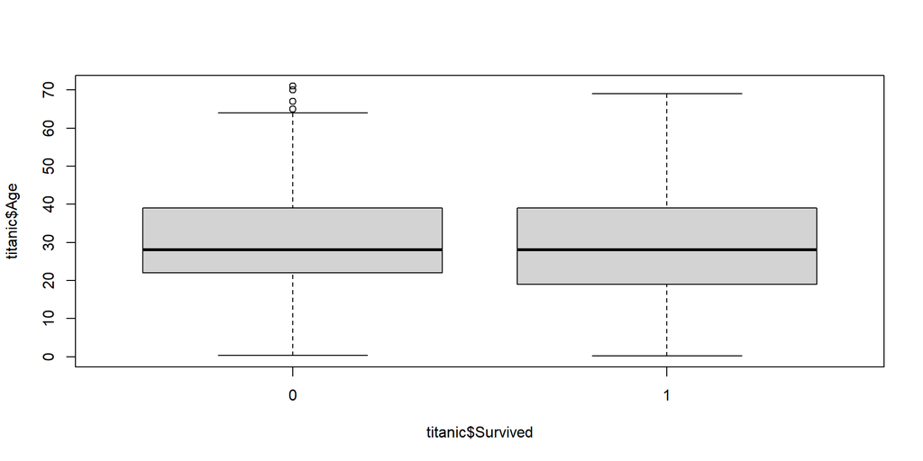

```r
boxplot(titanic$Age ~ titanic$Survived)
```

The means and distributions for the two groups are more or less the same. So we can already tell, that age by itself will not explain a lot of the variability in survival. Normally we would stop here and not fit a model with only Age as predictor for survival. However we will continue for exercise.

Fit the logistic regression model:

```r
lregm3 <- glm(data = titanic, Survived ~ Age, family = binomial(), na.action = "na.omit")
summary(lregm3)
```

```
##
## Call:
## glm(formula = Survived ~ Age, family = binomial(), data = titanic,
##     na.action = "na.omit")
##
## Deviance Residuals:
##     Min       1Q   Median       3Q      Max
## -1.1418  -1.0489  -0.9792   1.3039   1.4801
##
## Coefficients:
##              Estimate Std. Error z value Pr(>|z|)
## (Intercept) -0.081428   0.173862  -0.468   0.6395
## Age         -0.008795   0.005232  -1.681   0.0928 .
## ---
## Signif. codes:  0 '***' 0.001 '**' 0.01 '*' 0.05 '.' 0.1 ' ' 1
##
## (Dispersion parameter for binomial family taken to be 1)
##
##     Null deviance: 1025.6  on 755  degrees of freedom
## Residual deviance: 1022.7  on 754  degrees of freedom
##   (557 observations deleted due to missingness)
## AIC: 1026.7
##
## Number of Fisher Scoring iterations: 4
```

The found coefficients are not statistically significant at an alpha level of 0.05.

Lets look at the predictions made by the model: Get the probabilities of survival for each passenger with known age and what the prediction would be:

```r
prob_age <- predict(lregm3, type = "response")
pred_survived_age <- ifelse(prob_age > 0.5, 1, 0)
table(pred_survived_age)
```

```
## pred_survived_age
##   0
## 756
```

If we would choose 0.5 as cut off, the model predicts death for everybody. This could be explained by assuming that age does not help in predicting anything and because most people in the sample died, the model predicts death for everybody.

**Check Model Assumptions**

- Linearity Assumption

We have to check if there is a linear relationship between a continuous predictor and the logodds of the probability for a positive outcome (here survival).

We can check this by plotting the predictor variable versus the logodds of the outcome:

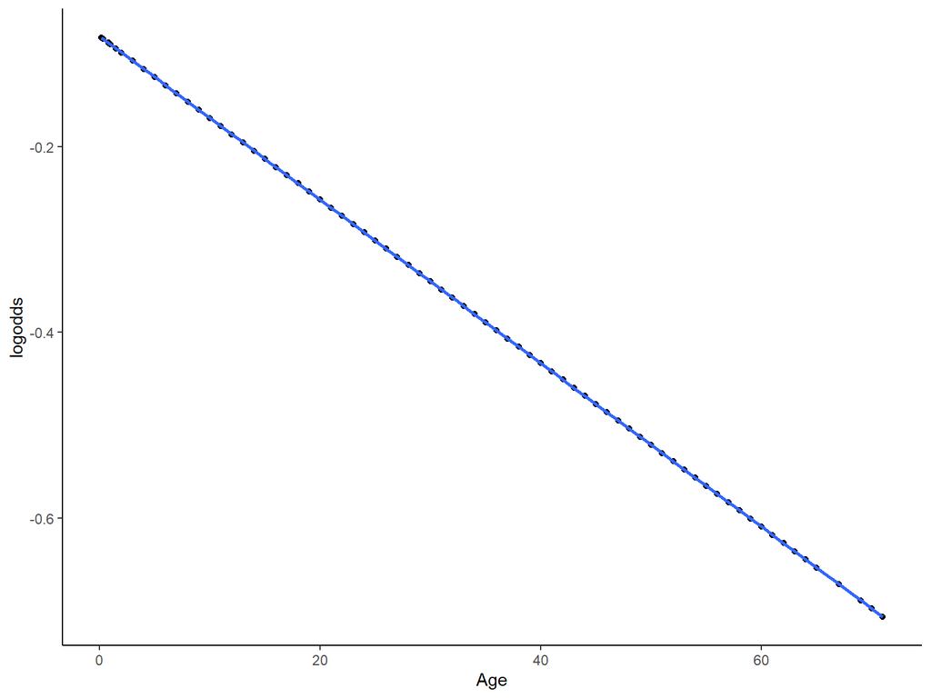

```r
titanic_age <- titanic %>%
  filter(is.na(Age) == FALSE) %>%
  cbind(., prob_age) %>%
  mutate(logodds = log(prob_age/(1-prob_age)))

titanic_age %>% ggplot(aes(x = Age, y = logodds))+
  geom_point() +
  geom_smooth(method = "loess") +
  theme_classic()
```

The fit is linear. However it seems like this must always be the case if only one continuous variable is used as predictor. Since the function just fits a linear model for the log(odds) to the predictor variable. This seems to be only important if multiple continuous predictors are used. This remains unclear to me.

- Influential values

We can inspect a plot of the Cooks distances for all the values.

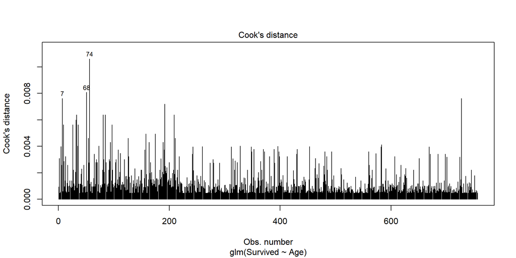

```r
plot(lregm3, which = 4, id.n = 3)
```

We get no values over the cut off of 1 and none that really stand out too much compared to the others. Therefore this assumption is fulfilled.

### 2.1.2 Multiple Logistic Regression

#### 2.1.2.1 Binary + Categorical Predictor Variables

We will use Sex and PClass together to model survival.

Lets look at a contingency table for Sex vs PClass to get an idea about the distributions:

```r
table(titanic$PClass, titanic$Sex)
```

```
##
##       female male
##   1st    143  179
##   2nd    107  173
##   3rd    212  499
```

In every class there are more males, this is most extreme in the third class.

Lets split the tables by survival:

```r
table(titanic$PClass, titanic$Sex, titanic$Survived)
```

```
## , ,  = 0
##
##
##       female male
##   1st      9  120
##   2nd     13  148
##   3rd    132  441
##
## , ,  = 1
##
##
##       female male
##   1st    134   59
##   2nd     94   25
##   3rd     80   58
```

We can calculate the survival probabilities for each class:

```r
p_survival <- data.frame(female = c(134/(9+134), 94/(13+94), 80/(132+80)), male = c(59/(120+59), 25/(148+25), 58/(441+58)))
row.names(p_survival) <- c("1st", "2nd", "3rd")
p_survival %>% kable(digits = 2)
```

|  | female | male |
| --- | --- | --- |
| 1st | 0.94 | 0.33 |
| 2nd | 0.88 | 0.14 |
| 3rd | 0.38 | 0.12 |

We see that females have a better probability for survival when adjusted for class and higher classes have better survival probabilities when adjusted for sex.

This confirms the tendencies that we had already seen when we used those two variables separately to fit a model.

Fit a model using both variables:

```r
mlregm1 <- glm(data = titanic, Survived ~ Sex + PClass, family = binomial())
summary(mlregm1)
```

```
##
## Call:
## glm(formula = Survived ~ Sex + PClass, family = binomial(), data = titanic)
##
## Deviance Residuals:
##     Min       1Q   Median       3Q      Max
## -2.0414  -0.6992  -0.3908   0.5156   2.2848
##
## Coefficients:
##             Estimate Std. Error z value Pr(>|z|)
## (Intercept)   1.9507     0.1718  11.356  < 2e-16 ***
## Sexmale      -2.4454     0.1512 -16.177  < 2e-16 ***
## PClass2nd    -0.7894     0.1954  -4.039 5.36e-05 ***
## PClass3rd    -2.0391     0.1774 -11.496  < 2e-16 ***
## ---
## Signif. codes:  0 '***' 0.001 '**' 0.01 '*' 0.05 '.' 0.1 ' ' 1
##
## (Dispersion parameter for binomial family taken to be 1)
##
##     Null deviance: 1688.1  on 1312  degrees of freedom
## Residual deviance: 1199.0  on 1309  degrees of freedom
## AIC: 1207
##
## Number of Fisher Scoring iterations: 5
```

All of the coefficients differ significantly from zero at an alpha of 0.05. We can compare the Residual Deviance and the AIC to the two models that used only one of the predictors.  
Both values are smaller for this model then for the other two.  
The AIC value is a measure for how parsimonious the model is and a lower value is better. Therefore, using this as a measure the model using both variables should be preferred.  
The residual deviance measures how well the model can predict the outcome and a lower values is better.  
So the model improved in both aspects.

**Check Model Assumptions**

Again, there is not much to test here. The assumptions are the same as for the chi squared test. The observations are independent and the cells in the contingency table are mutually exclusive.

#### 2.1.2.2 Categorical + Continuous Predictor Variables

We will use PClass and Age as predictors for survival.

lets look at the age distributions for each PClass:

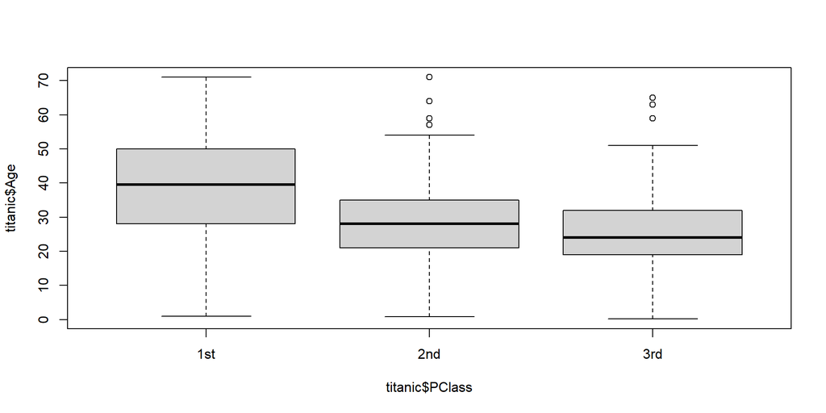

```r
boxplot(titanic$Age ~ titanic$PClass)
```

There is a decrease of the mean from 1st to 2nd and 2nd to 3rd class. There is quite a lot of overlap though.

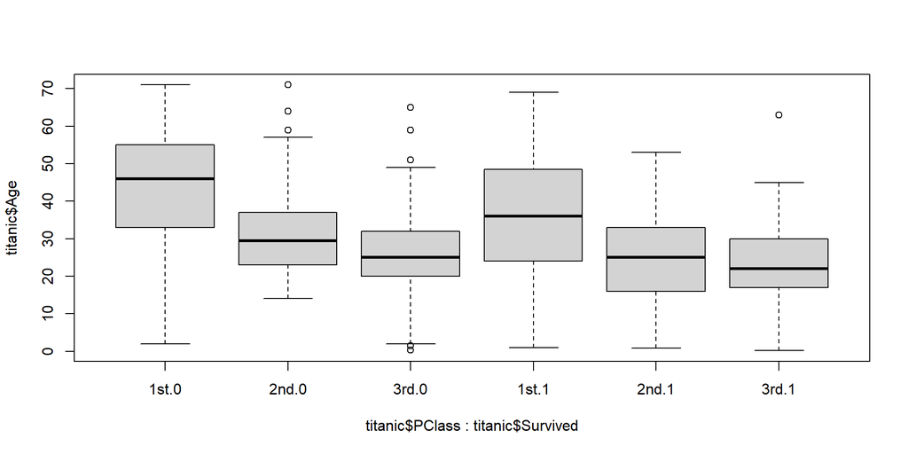

```r
boxplot(titanic$Age ~ titanic$PClass + titanic$Survived)
```

When we split the data by survival, we see again a decrease in the mean age from 1st to 2nd and 2nd to 3rd class (in both, the groups that survived and those that died). We also see that the groups that survived have a lower mean than those that did not survive (adjusted for class).

Instead of a box plot it might be interesting to see a density plot for each of the groups (violin plot):

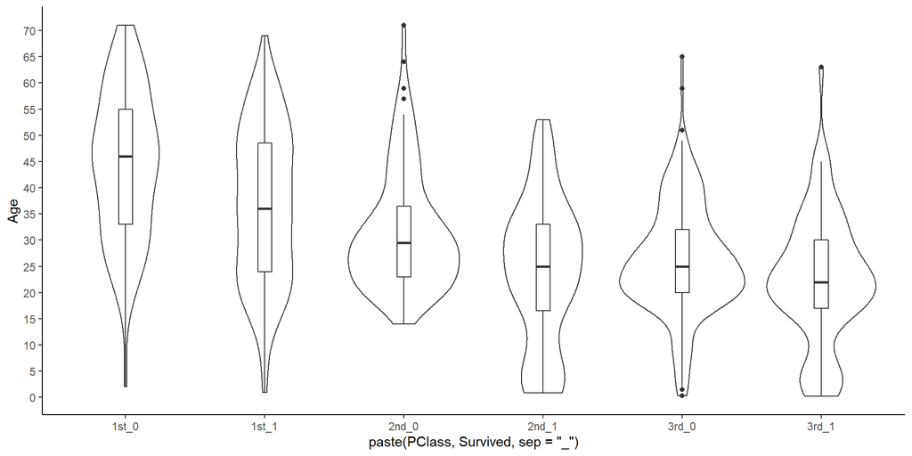

```r
titanic %>% ggplot(aes(x = paste(PClass, Survived, sep = "_"), y = Age)) +
  geom_violin() +
  geom_boxplot(width=0.1) +
  scale_y_continuous(breaks=seq(0,75,by=5)) +
  theme_classic()
```

Here we can see, that not many children (under the age of 10-15) died. In the 1st class more older people died, but there is still quite some overlap. In the 2nd class no people over 55 survived and no people under ca. 13 died, for the ages in between the distributions look very similar between the survived and dead groups. In the 3rd class more children survived (not all) and the point with maximal density is a bit lower for the group that survived. The group of the people that died has a higher density at the higher ages of the group (>35).

From these plots we can already see that the relationship between age and survival is confounded by PClass, since PClass is related to age as well as survival. Therefore the model combining the two should be “better” then the models fit for the variables individually.

Fit a model with the two variables:

```r
mlregm2 <- glm(data = titanic, Survived ~ Age + PClass, family = binomial())
summary(mlregm2)
```

```
##
## Call:
## glm(formula = Survived ~ Age + PClass, family = binomial(), data = titanic)
##
## Deviance Residuals:
##     Min       1Q   Median       3Q      Max
## -2.0440  -0.9426  -0.6551   1.0959   2.3210
##
## Coefficients:
##              Estimate Std. Error z value Pr(>|z|)
## (Intercept)  2.033706   0.306880   6.627 3.43e-11 ***
## Age         -0.038504   0.006546  -5.882 4.05e-09 ***
## PClass2nd   -1.145820   0.220260  -5.202 1.97e-07 ***
## PClass3rd   -2.231504   0.228993  -9.745  < 2e-16 ***
## ---
## Signif. codes:  0 '***' 0.001 '**' 0.01 '*' 0.05 '.' 0.1 ' ' 1
##
## (Dispersion parameter for binomial family taken to be 1)
##
##     Null deviance: 1025.57  on 755  degrees of freedom
## Residual deviance:  909.92  on 752  degrees of freedom
##   (557 observations deleted due to missingness)
## AIC: 917.92
##
## Number of Fisher Scoring iterations: 4
```

In order to assess if there is statistically significant confounding we can compare the coefficients from the adjusted and unadjusted models.

```r
mlregm2_comp_coef <- data.frame(unadjusted_coeff = c(-0.7052, -1.8265, -0.008795),
                                unadjusted_lci = c(-0.7052-1.96*0.1660, -1.8265-1.96*0.1481, -0.008795-1.96*0.005232),
                                unadjusted_uci = c(-0.7052+1.96*0.1660, -1.8265+1.96*0.1481, -0.008795+1.96*0.005232),
                                adjusted_coeff = c(-1.145820, -2.231504, -0.038504),
                                adjusted_lci = c(-1.145820-1.96*0.220260, -2.231504-1.96*0.228993, -0.038504-1.96*0.006546),
                                adjusted_uci = c(-1.145820+1.96*0.220260, -2.231504+1.96*0.228993, -0.038504+1.96*0.006546))
row.names(mlregm2_comp_coef) <- c("PClass2nd", "PClass3rd", "Age")
mlregm2_comp_coef %>% kable(digits = 2)
```

|  | unadjusted_coeff | unadjusted_lci | unadjusted_uci | adjusted_coeff | adjusted_lci | adjusted_uci |
| --- | --- | --- | --- | --- | --- | --- |
| PClass2nd | -0.71 | -1.03 | -0.38 | -1.15 | -1.58 | -0.71 |
| PClass3rd | -1.83 | -2.12 | -1.54 | -2.23 | -2.68 | -1.78 |
| Age | -0.01 | -0.02 | 0.00 | -0.04 | -0.05 | -0.03 |

We see that there was a statistically significant change in the slope for Age, since the adjusted and unadjusted CIs exclude each other. This confirms that there was statistically significant confounding of the association between Age and survival.  
There where also quite big changes in magnitudes of the two PClass coefficients, those are however not statistically significant.

Lets see how the model fits the data here, by plotting age against the probability for survival and grouping by PClass:

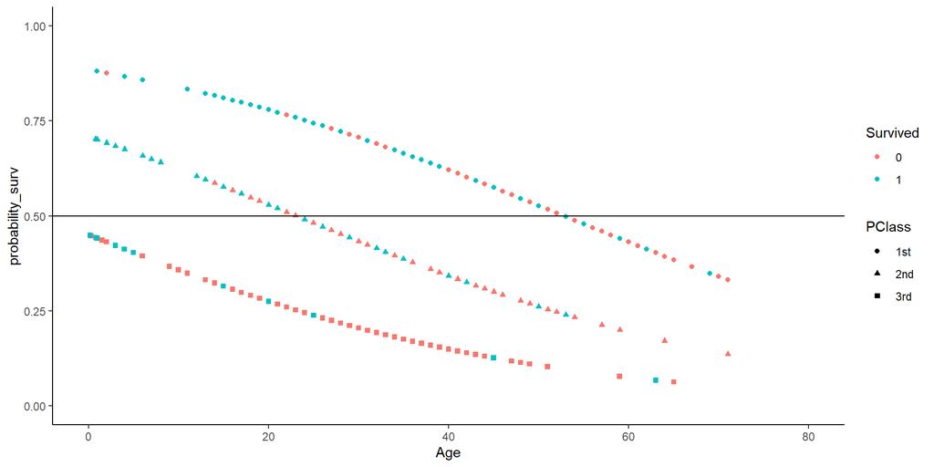

```r
mlregm2_ps <- cbind(titanic[is.na(titanic$Age) == FALSE,], probability_surv = predict(mlregm2, type = "response"))

ggplot(data = mlregm2_ps, aes(x = Age, y = probability_surv, shape = PClass, color = as.factor(Survived))) +
  geom_point() +
  xlim(0, 80) +
  ylim(0, 1) +
  geom_hline(yintercept = 0.5) +
  guides(color = guide_legend(title = "Survived")) +
  theme_classic()
```

We can see that for all classes the probability for survival decrease with higher age and with higher PClass. The fit of the third class could probably be improve (the young children could be predicted to survive)

We can also fit a model with interaction terms, to see if there is statistically significant effect modification.

```r
mlregm3 <- glm(data = titanic, Survived ~ Age + PClass + Age*PClass, family = binomial())
summary(mlregm3)
```

```
##
## Call:
## glm(formula = Survived ~ Age + PClass + Age * PClass, family = binomial(),
##     data = titanic)
##
## Deviance Residuals:
##     Min       1Q   Median       3Q      Max
## -1.9986  -0.9086  -0.6687   1.0746   2.2023
##
## Coefficients:
##                Estimate Std. Error z value Pr(>|z|)
## (Intercept)    1.922980   0.436246   4.408 1.04e-05 ***
## Age           -0.035838   0.009955  -3.600 0.000318 ***
## PClass2nd     -0.744277   0.571547  -1.302 0.192843
## PClass3rd     -2.290072   0.540573  -4.236 2.27e-05 ***
## Age:PClass2nd -0.013209   0.015869  -0.832 0.405188
## Age:PClass3rd  0.004642   0.015941   0.291 0.770896
## ---
## Signif. codes:  0 '***' 0.001 '**' 0.01 '*' 0.05 '.' 0.1 ' ' 1
##
## (Dispersion parameter for binomial family taken to be 1)
##
##     Null deviance: 1025.57  on 755  degrees of freedom
## Residual deviance:  908.75  on 750  degrees of freedom
##   (557 observations deleted due to missingness)
## AIC: 920.75
##
## Number of Fisher Scoring iterations: 4
```

The AIC and residual deviance are very close to the ones of the model without the interaction terms. The interaction terms dont differ significantly from zero. Both these facts suggest, that the interaction terms dont add anything to the model and that there is probably no effect modification of PClass on the association between Age and survival (and the other way around).

Repeat the plot from above for the probabilities given by the model with interaction terms:

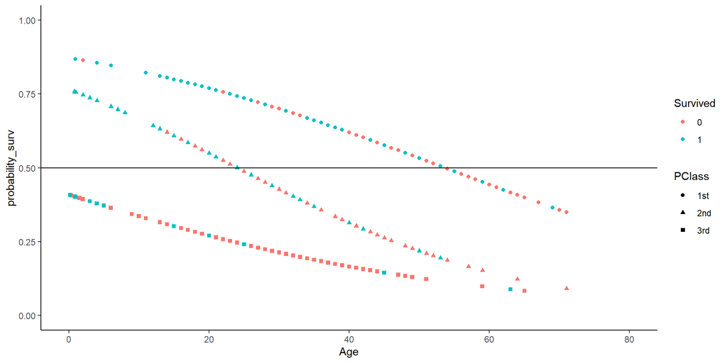

```r
mlregm3_ps <- cbind(titanic[is.na(titanic$Age) == FALSE,], probability_surv = predict(mlregm3, type = "response"))

ggplot(data = mlregm3_ps, aes(x = Age, y = probability_surv, shape = PClass, color = as.factor(Survived))) +
  geom_point() +
  xlim(0, 80) +
  ylim(0, 1) +
  geom_hline(yintercept = 0.5) +
  guides(color = guide_legend(title = "Survived")) +
  theme_classic()
```

Visually there is no big difference to the model without the interaction terms.

**Check Model Assumptions**

- Linearity Assumption

We have already checked this for Age above.

- Influential values

We can inspect a plot of the Cooks distances for all the values.

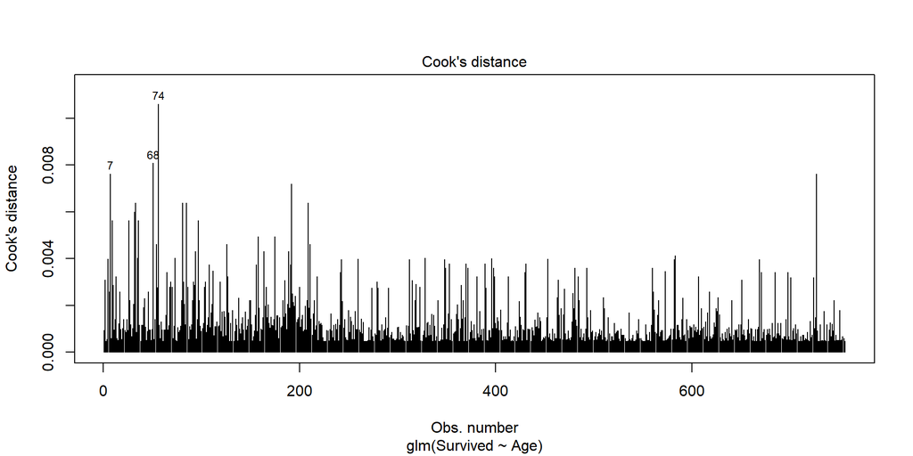

```r
plot(lregm3, which = 4, id.n = 3)
```

#### 2.1.2.3 Binary + Categorical + Continuous Predictor Variables

We will now use Sex, PClass and Age together as predictors:

Lets look at the distributions of age in the different groups (combinations of survival, Sex and PClass):

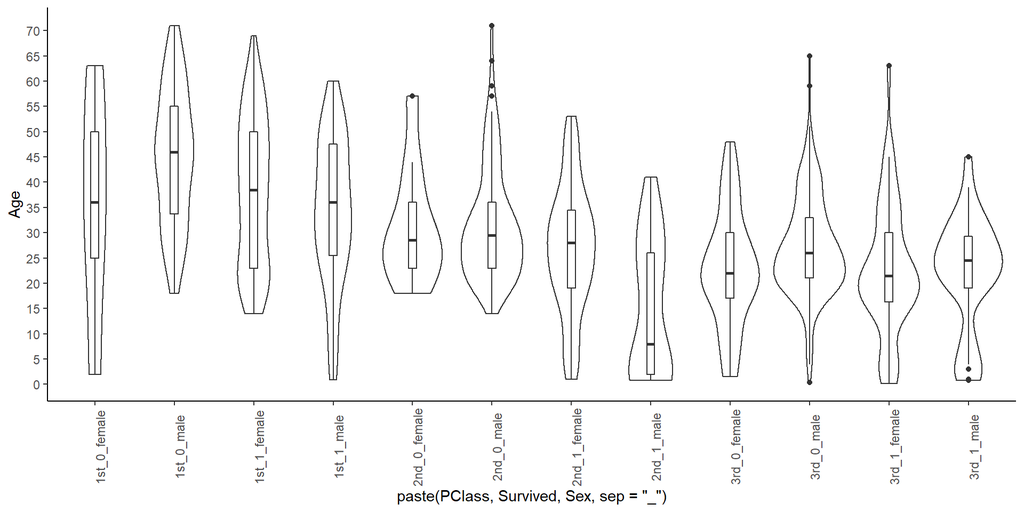

```r
titanic %>% ggplot(aes(x = paste(PClass, Survived, Sex,  sep = "_"), y = Age)) +
  geom_violin() +
  geom_boxplot(width=0.1) +
  scale_y_continuous(breaks=seq(0,75,by=5)) +
  theme_classic() +
  theme(axis.text.x = element_text(angle = 90))
```

There are differences between the distributions for males and females, however they are not always what we would expect intuitively / dont follow the general trends in the data we had previously seen. For example in 1st class there are some female children that died, while no male children died. Or in 3rd class more female children than male children died. It is possible that “the rules change” between different age groups (e.g. for children). Maybe male children had a better chance of survival. This would indicate that there is effect modification of the association of Sex/PClass with survival by Age (and the other way around). Or it could just be due to outliers.

```r
mlregm4 <- glm(data = titanic, Survived ~ Age + PClass + Sex, family = binomial())
summary(mlregm4)
```

```
##
## Call:
## glm(formula = Survived ~ Age + PClass + Sex, family = binomial(),
##     data = titanic)
##
## Deviance Residuals:
##     Min       1Q   Median       3Q      Max
## -2.7226  -0.7065  -0.3917   0.6495   2.5289
##
## Coefficients:
##              Estimate Std. Error z value Pr(>|z|)
## (Intercept)  3.759662   0.397567   9.457  < 2e-16 ***
## Age         -0.039177   0.007616  -5.144 2.69e-07 ***
## PClass2nd   -1.291962   0.260076  -4.968 6.78e-07 ***
## PClass3rd   -2.521419   0.276657  -9.114  < 2e-16 ***
## Sexmale     -2.631357   0.201505 -13.058  < 2e-16 ***
## ---
## Signif. codes:  0 '***' 0.001 '**' 0.01 '*' 0.05 '.' 0.1 ' ' 1
##
## (Dispersion parameter for binomial family taken to be 1)
##
##     Null deviance: 1025.57  on 755  degrees of freedom
## Residual deviance:  695.14  on 751  degrees of freedom
##   (557 observations deleted due to missingness)
## AIC: 705.14
##
## Number of Fisher Scoring iterations: 5
```

The AIC as well as the residual deviance improved quite a lot compared to the model using Age and PClass as predictor.  
All the coefficients are significantly different from zero.  
In order to see if there is statistically significant confounding we will calculate the 95% CIs of all the unadjusted and adjusted associations and then see if they overlap:

```r
mlregm4_comp_coef <- data.frame(unadjusted_coeff = c(-0.7052, -1.8265, -0.008795, -2.30118),
                                unadjusted_lci = c(-0.7052-1.96*0.1660, -1.8265-1.96*0.1481, -0.008795-1.96*0.005232, -2.30118-1.96*0.13488),
                                unadjusted_uci = c(-0.7052+1.96*0.1660, -1.8265+1.96*0.1481, -0.008795+1.96*0.005232, -2.30118+1.96*0.13488),
                                adjusted_coeff = c(-1.291962, -2.521419, -0.039177, -2.631357),
                                adjusted_lci = c(-1.291962-1.96*0.260076, -2.521419-1.96*0.276657, -0.039177-1.96*0.007616,
                                                 -2.631357-1.96*0.201505),
                                adjusted_uci = c(-1.291962+1.96*0.260076, -2.521419+1.96*0.276657, -0.039177+1.96*0.007616,
                                                 -2.631357+1.96*0.201505))
row.names(mlregm4_comp_coef) <- c("PClass2nd", "PClass3rd", "Age", "Sex")
mlregm4_comp_coef %>% kable(digits = 3)
```

|  | unadjusted_coeff | unadjusted_lci | unadjusted_uci | adjusted_coeff | adjusted_lci | adjusted_uci |
| --- | --- | --- | --- | --- | --- | --- |
| PClass2nd | -0.705 | -1.031 | -0.380 | -1.292 | -1.802 | -0.782 |
| PClass3rd | -1.826 | -2.117 | -1.536 | -2.521 | -3.064 | -1.979 |
| Age | -0.009 | -0.019 | 0.001 | -0.039 | -0.054 | -0.024 |
| Sex | -2.301 | -2.566 | -2.037 | -2.631 | -3.026 | -2.236 |

- For PClass the coefficients change with adjustment for Sex and Age, but the difference is not statistically significant.
- For Age the coefficient changes with adjustment for PClass and Sex and the difference is statistically significant.
- For Sex the coefficient changes with adjustment for PClass and Age, but the difference is not statistically significant.

Plot Age against probability of survival for the different combinations of Sex and PClass:

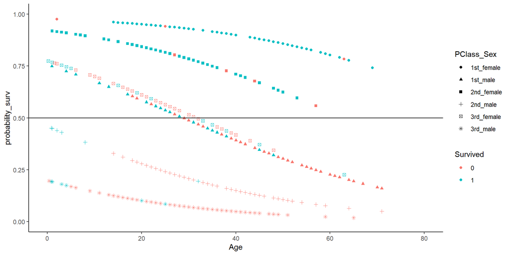

```r
mlregm4_ps <- cbind(titanic[is.na(titanic$Age) == FALSE,], probability_surv = predict(mlregm4, type = "response"))

mlregm4_fit <- ggplot(data = mlregm4_ps, aes(x = Age, y = probability_surv, shape = paste(PClass, Sex, sep = "_"), color = as.factor(Survived))) +
  geom_point() +
  xlim(0, 80) +
  ylim(0, 1) +
  geom_hline(yintercept = 0.5) +
  guides(shape = guide_legend(title = "PClass_Sex")) +
  guides(color = guide_legend(title = "Survived")) +
  theme_classic()

mlregm4_fit
```

Lets check if there is effect modification by Age on the association between the PClass/Sex and Survival.  
Fit a model with interaction terms of Sex and PClass with Age:

```r
mlregm5 <- glm(data = titanic,
               Survived ~ Age + PClass + Sex + Age*PClass + Age*Sex
               ,family = binomial())
summary(mlregm5)
```

```
##
## Call:
## glm(formula = Survived ~ Age + PClass + Sex + Age * PClass +
##     Age * Sex, family = binomial(), data = titanic)
##
## Deviance Residuals:
##     Min       1Q   Median       3Q      Max
## -2.6858  -0.6459  -0.3392   0.6751   2.7271
##
## Coefficients:
##               Estimate Std. Error z value Pr(>|z|)
## (Intercept)    2.02992    0.65977   3.077  0.00209 **
## Age            0.02459    0.01975   1.245  0.21310
## PClass2nd     -0.21153    0.71014  -0.298  0.76580
## PClass3rd     -2.08114    0.66578  -3.126  0.00177 **
## Sexmale       -0.38894    0.48027  -0.810  0.41804
## Age:PClass2nd -0.04506    0.02195  -2.053  0.04012 *
## Age:PClass3rd -0.01481    0.02113  -0.701  0.48337
## Age:Sexmale   -0.08209    0.01707  -4.809 1.52e-06 ***
## ---
## Signif. codes:  0 '***' 0.001 '**' 0.01 '*' 0.05 '.' 0.1 ' ' 1
##
## (Dispersion parameter for binomial family taken to be 1)
##
##     Null deviance: 1025.57  on 755  degrees of freedom
## Residual deviance:  662.45  on 748  degrees of freedom
##   (557 observations deleted due to missingness)
## AIC: 678.45
##
## Number of Fisher Scoring iterations: 5
```

The AIC as well as the residual deviance decreased slightly compared to the model without the interaction terms.  
The interaction terms for Age and PClass = 2 as well as Age and Sex are statistically significant. The one for Age with PClass = 3rd is not.  
The intercept in this model represents the estimate of the log(odds) for females with PClass = 1 at Age zero. It is statistically significant as well. This is good because there is data that is close to the intercept (females in PClass = 1 of very young age).  
The coefficient for the 3rd PClass is statistically significant, while the coefficients for Age, 2nd PClass, Sex = male are no longer statistically significant.

The results of the model can be interpreted as follows:  
- The relationship between Age and Survival is different for males and females (it is advantageous to fit a different slope)  
- The relationship between Age and Survival is different between 1st and 2nd class. For the 3rd class the relationship does not differ significantly from the 1st class.

Plot Age against probability of survival:

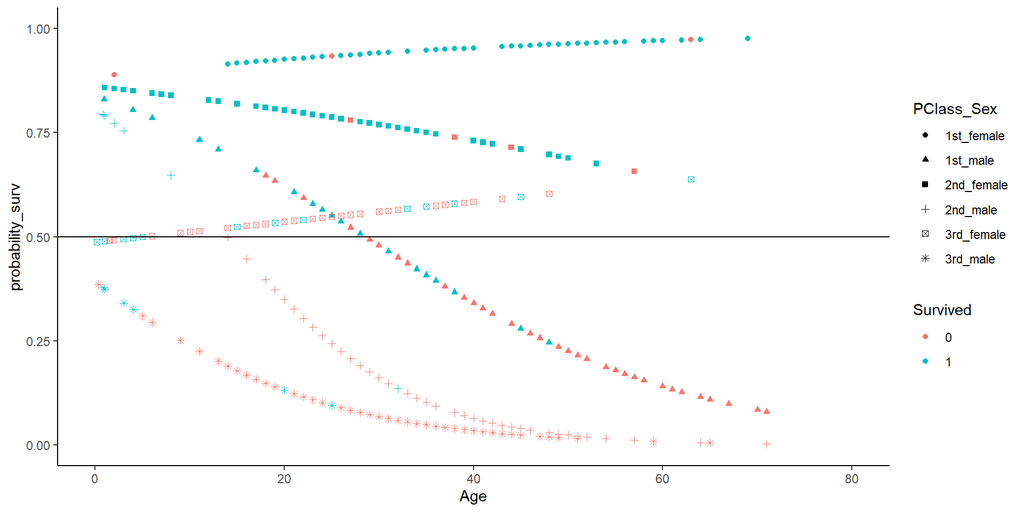

```r
mlregm5_ps <- cbind(titanic[is.na(titanic$Age) == FALSE,], probability_surv = predict(mlregm5, type = "response"))

mlregm5_fit <- ggplot(data = mlregm5_ps, aes(x = Age, y = probability_surv, shape = paste(PClass, Sex, sep = "_"), color = as.factor(Survived))) +
  geom_point() +
  xlim(0, 80) +
  ylim(0, 1) +
  geom_hline(yintercept = 0.5) +
  guides(shape = guide_legend(title = "PClass_Sex")) +
  guides(color = guide_legend(title = "Survived")) +
  theme_classic()

mlregm5_fit
```

We can see that some of the slopes of the fit for females in 1st and 3rd class changed direction, meaning higher Age would increase probability for survival. For the females in the 3rd class this doesnt make much sense.

Lets compare the plots of the fit for both models side by side:

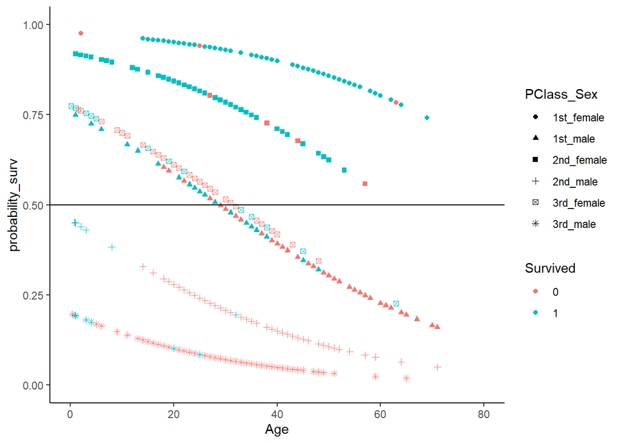

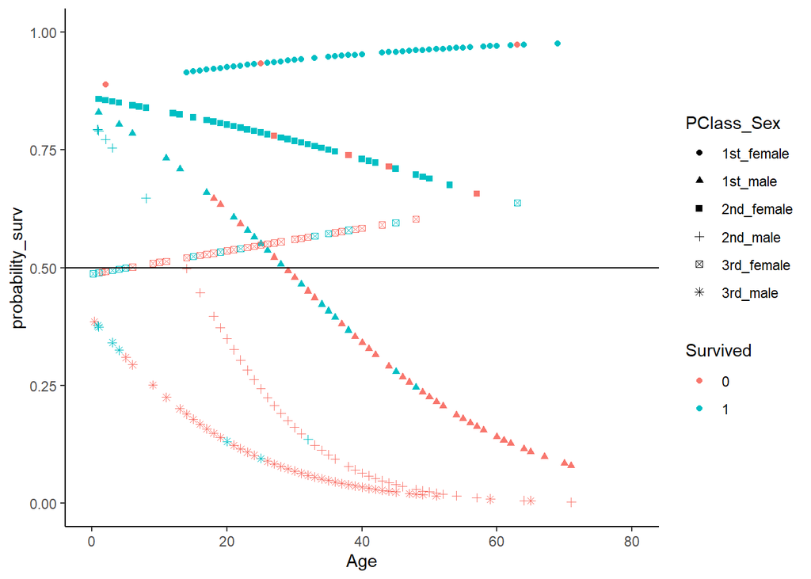

```r
mlregm4_fit
mlregm5_fit
```

The curves for males in 2nd and 3rd class seem better in the model with interaction terms, as they descend more with Age. Otherwise it doesnt seem like one of the models is clearly better at separating the true values.

Lets also fit a model with interaction terms for PCLass and Sex:

```r
mlregm6 <- glm(data = titanic,
               Survived ~ Age + PClass + Sex + Age*PClass + Age*Sex + Sex*PClass
               ,family = binomial())
summary(mlregm6)
```

```
##
## Call:
## glm(formula = Survived ~ Age + PClass + Sex + Age * PClass +
##     Age * Sex + Sex * PClass, family = binomial(), data = titanic)
##
## Deviance Residuals:
##     Min       1Q   Median       3Q      Max
## -2.5882  -0.6394  -0.3678   0.4206   2.7230
##
## Coefficients:
##                    Estimate Std. Error z value Pr(>|z|)
## (Intercept)        2.463599   0.845664   2.913 0.003577 **
## Age                0.013492   0.020250   0.666 0.505246
## PClass2nd          1.117752   1.018111   1.098 0.272262
## PClass3rd         -2.807199   0.833634  -3.367 0.000759 ***
## Sexmale           -0.946499   0.833357  -1.136 0.256055
## Age:PClass2nd     -0.065120   0.024761  -2.630 0.008539 **
## Age:PClass3rd     -0.007055   0.020288  -0.348 0.728047
## Age:Sexmale       -0.068052   0.018607  -3.657 0.000255 ***
## PClass2nd:Sexmale -1.410385   0.729056  -1.935 0.053047 .
## PClass3rd:Sexmale  1.033269   0.625510   1.652 0.098558 .
## ---
## Signif. codes:  0 '***' 0.001 '**' 0.01 '*' 0.05 '.' 0.1 ' ' 1
##
## (Dispersion parameter for binomial family taken to be 1)
##
##     Null deviance: 1025.57  on 755  degrees of freedom
## Residual deviance:  641.37  on 746  degrees of freedom
##   (557 observations deleted due to missingness)
## AIC: 661.37
##
## Number of Fisher Scoring iterations: 5
```

The residual deviance and AIC are again a bit lower then in the last model.

Plot again Age against predicted probability for survival:

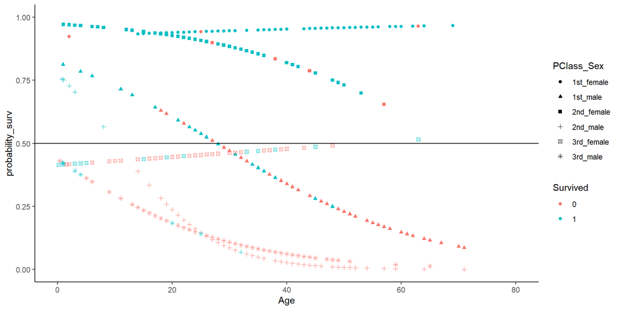

```r
mlregm6_ps <- cbind(titanic[is.na(titanic$Age) == FALSE,], probability_surv = predict(mlregm6, type = "response"))

ggplot(data = mlregm6_ps, aes(x = Age, y = probability_surv, shape = paste(PClass, Sex, sep = "_"), color = as.factor(Survived))) +
  geom_point() +
  xlim(0, 80) +
  ylim(0, 1) +
  geom_hline(yintercept = 0.5) +
  guides(shape = guide_legend(title = "PClass_Sex")) +
  guides(color = guide_legend(title = "Survived")) +
  theme_classic()
```

Here females in 3rd class are almost all predicted to die.

Including PClass, Sex and Age as predictors is clearly advantageous, compared to only PClass and Age. It is a bit unclear if the small improvement in residual deviance and AIC of the models with interaction terms justify the increase of the model complexity by introducing them.

**Check Model Assumptions**

- Linearity Assumption

We have already checked this for Age above. As we did not add any new continuous variables there is no need to redo this.

- Influential values

We can inspect a plot of the Cooks distances for all the values.

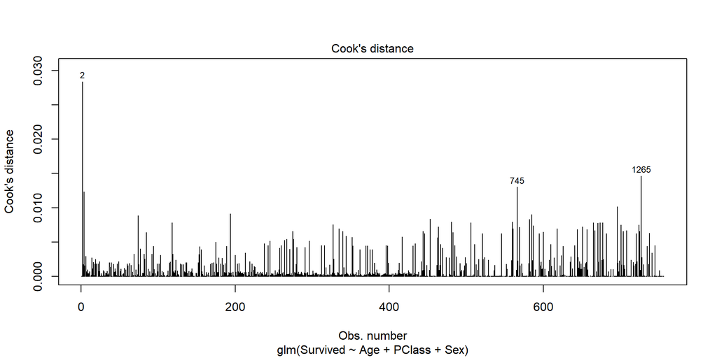

```r
plot(mlregm4, which = 4, id.n = 3)
```

Looks ok. Record number two is quite influential. This is a female 1st class passenger of age 2, who died. It makes sense that this would be influential, as she had all the attributes that would generally predict survival, but she died. So the record goes against the majority of the other data and therefore the fit model.

### 2.1.3 Possible further inqueries

Since we had already used all of the possible predictor variables (except name) there aren’t any additional variables that could be included in the model.

However one could try to make age groups and use it as a categorical variable. This might make sense, since the relationship to survival probably is not really linear, but maybe more a step function, meaning the probability for survival probably changes when one enters a new age category, rather then if one is 1 year younger or older.  
For example children under under ca. 15 years have a different probability and there probably is no big difference if a child is 5 or 6 years old.  
Older people on the other side have a decreased probability of survival. Here the cut off seems not to be that clear as for children and would be harder to find. Maybe Age could just be replaced with a binary variable that indicates if the person is under 15 years old.  
The problem with the Age variable is the high number of missing values. We could try to impute those, which would also be simplified by transforming it into a categorical variable.

From the names variable one could try to exctract certain information, such as:  
- Marriage status (Miss vs. Mrs) and to whom they are married (the name of the husband is included in their name). One could imagine that survival of the partners might correlate.  
- Title, which could give some clues about social status (Dr., Major etc.) or Age (Master for male children). For these we would then have to make sure if they correlate with PClass, or Age (or a categorical version of Age) and which to then include in the model.

### 2.1.4 Create a Title Variable

Initially it was not planned to do this, but I got curious about variable that contains the title when writing the section above. We will only do a quick analysis.

We will extract the title from the name of the passenger and fit a model with it.

Create title variable:

```r
titanic <- titanic %>% mutate(Title_0 = sub("^.*?, ", "", x = .$Name)) %>%
        mutate(Title = as.factor(sub(" .*", "", x = .$Title_0))) %>%
        select(!Title_0)
```

What distinct values did we get?

```r
summary(titanic$Title)
```

```
##    Albert   Captain       Col   Colonel     Delia        Dr      Eino     Ernst
##         1         1         2         2         1         8         1         1
##     Hilda Jacobsohn     Jenny  Jonkheer    Khalil      Lady       Leo    Madame
##         1         1         1         1         1         1         1         1
##     Major  Mansouer    Master      Miss      Mlle        Mr       Mrs        Ms
##         2         1        59       236         2       750       200        17
##   Nikolai      Nils     Oscar       Rev   Richard    Sander     Seman     Simon
##         1         1         1         8         1         1         1         1
##       Sir       the    Thomas         W   William
##         1         1         2         1         1
```

There are some instances, where we did not get the title, but a name or another word. We will exclude all the records with values that occur less then three times (since we are just doing a quick analysis):

```r
titanic_t <- titanic %>% group_by(Title) %>%
        mutate(count=n()) %>%
        filter(count > 3) %>%
        select(!count)

#drop the excluded levels
titanic_t$Title <- droplevels(titanic_t$Title)
```

Tabulate the title split by survival:

```r
table(titanic_t$Title, titanic_t$Survived)
```

```
##
##            0   1
##   Dr       4   4
##   Master  36  23
##   Miss    97 139
##   Mr     642 108
##   Mrs     51 149
##   Ms       3  14
##   Rev      8   0
```

The separation is not perfect and there are some counter intuitive numbers, for example I would have expected that most of the “Masters” would have survived.

Fit a model:

```r
mlregm7 <- glm(data = titanic_t,
               Survived ~ Title
               ,family = binomial())
summary(mlregm7)
```

```
##
## Call:
## glm(formula = Survived ~ Title, family = binomial(), data = titanic_t)
##
## Deviance Residuals:
##     Min       1Q   Median       3Q      Max
## -1.8626  -0.5576  -0.5576   0.7673   1.9687
##
## Coefficients:
##               Estimate Std. Error z value Pr(>|z|)
## (Intercept) -2.760e-13  7.071e-01   0.000   1.0000
## TitleMaster -4.480e-01  7.558e-01  -0.593   0.5533
## TitleMiss    3.598e-01  7.194e-01   0.500   0.6170
## TitleMr     -1.782e+00  7.147e-01  -2.494   0.0126 *
## TitleMrs     1.072e+00  7.255e-01   1.478   0.1395
## TitleMs      1.540e+00  9.512e-01   1.619   0.1053
## TitleRev    -1.557e+01  5.146e+02  -0.030   0.9759
## ---
## Signif. codes:  0 '***' 0.001 '**' 0.01 '*' 0.05 '.' 0.1 ' ' 1
##
## (Dispersion parameter for binomial family taken to be 1)
##
##     Null deviance: 1641.8  on 1277  degrees of freedom
## Residual deviance: 1270.8  on 1271  degrees of freedom
## AIC: 1284.8
##
## Number of Fisher Scoring iterations: 14
```

The AIC and residual deviance are not very good compared to the model with Sex, Age and PClass. The only coefficient that differs significantly from zero is the one for Mr.

Lets fit a model including also PClass, since the title does not contain any information about the class (the only hint could be the title Dr, which we could expect to be in 1st class):

```r
mlregm8 <- glm(data = titanic_t,
               Survived ~ Title + PClass
               ,family = binomial())
summary(mlregm8)
```

```
##
## Call:
## glm(formula = Survived ~ Title + PClass, family = binomial(),
##     data = titanic_t)
##
## Deviance Residuals:
##     Min       1Q   Median       3Q      Max
## -2.1698  -0.6402  -0.3348   0.6231   2.4122
##
## Coefficients:
##             Estimate Std. Error z value Pr(>|z|)
## (Intercept)   0.2111     0.7208   0.293  0.76960
## TitleMaster   1.1124     0.7867   1.414  0.15736
## TitleMiss     1.8022     0.7463   2.415  0.01574 *
## TitleMr      -0.8276     0.7301  -1.133  0.25701
## TitleMrs      2.0430     0.7483   2.730  0.00633 **
## TitleMs       1.3293     0.9614   1.383  0.16677
## TitleRev    -14.9128   514.5613  -0.029  0.97688
## PClass2nd    -0.8644     0.2108  -4.102  4.1e-05 ***
## PClass3rd    -2.2369     0.1994 -11.218  < 2e-16 ***
## ---
## Signif. codes:  0 '***' 0.001 '**' 0.01 '*' 0.05 '.' 0.1 ' ' 1
##
## (Dispersion parameter for binomial family taken to be 1)
##
##     Null deviance: 1641.8  on 1277  degrees of freedom
## Residual deviance: 1115.3  on 1269  degrees of freedom
## AIC: 1133.3
##
## Number of Fisher Scoring iterations: 14
```

The two scores improved a bit, but not that much.

Lets try to add Age as well:

```r
mlregm9 <- glm(data = titanic_t,
               Survived ~ Title + PClass + Age
               ,family = binomial())
summary(mlregm9)
```

```
##
## Call:
## glm(formula = Survived ~ Title + PClass + Age, family = binomial(),
##     data = titanic_t)
##
## Deviance Residuals:
##     Min       1Q   Median       3Q      Max
## -2.5029  -0.6559  -0.3306   0.5848   2.5814
##
## Coefficients:
##               Estimate Std. Error z value Pr(>|z|)
## (Intercept)   1.156576   1.037642   1.115  0.26501
## TitleMaster   1.680251   1.074973   1.563  0.11804
## TitleMiss     1.915585   0.988228   1.938  0.05257 .
## TitleMr      -0.726185   0.963734  -0.754  0.45114
## TitleMrs      2.623980   0.987010   2.659  0.00785 **
## TitleRev    -14.465964 588.989165  -0.025  0.98041
## PClass2nd    -1.220162   0.280512  -4.350 1.36e-05 ***
## PClass3rd    -2.478335   0.294642  -8.411  < 2e-16 ***
## Age          -0.027719   0.009359  -2.962  0.00306 **
## ---
## Signif. codes:  0 '***' 0.001 '**' 0.01 '*' 0.05 '.' 0.1 ' ' 1
##
## (Dispersion parameter for binomial family taken to be 1)
##
##     Null deviance: 1001.13  on 738  degrees of freedom
## Residual deviance:  630.51  on 730  degrees of freedom
##   (539 observations deleted due to missingness)
## AIC: 648.51
##
## Number of Fisher Scoring iterations: 14
```

This improves the model quite a lot. So there might be a certain added value. However it is difficult to say, since the inclusion of Age leads to all the records with NA values to be excluded, so we cannot really compare the two models directly.

We have to fit a model with Title and PClass only including the records where Age is not NA:

```r
#filter out Age == NA
titanic_t_a <- titanic_t %>% filter(!is.na(Age))
#fit model
mlregm10 <- glm(data = titanic_t_a,
               Survived ~ Title + PClass
               ,family = binomial())
summary(mlregm10)
```

```
##
## Call:
## glm(formula = Survived ~ Title + PClass, family = binomial(),
##     data = titanic_t_a)
##
## Deviance Residuals:
##     Min       1Q   Median       3Q      Max
## -2.2807  -0.6007  -0.3404   0.6067   2.3988
##
## Coefficients:
##              Estimate Std. Error z value Pr(>|z|)
## (Intercept)  -0.05915    0.93858  -0.063 0.949748
## TitleMaster   2.42588    1.02941   2.357 0.018444 *
## TitleMiss     2.26322    0.96607   2.343 0.019145 *
## TitleMr      -0.63737    0.94640  -0.673 0.500650
## TitleMrs      2.58284    0.96956   2.664 0.007724 **
## TitleRev    -14.58246  594.16431  -0.025 0.980420
## PClass2nd    -0.92446    0.25823  -3.580 0.000344 ***
## PClass3rd    -2.12273    0.26313  -8.067  7.2e-16 ***
## ---
## Signif. codes:  0 '***' 0.001 '**' 0.01 '*' 0.05 '.' 0.1 ' ' 1
##
## (Dispersion parameter for binomial family taken to be 1)
##
##     Null deviance: 1001.13  on 738  degrees of freedom
## Residual deviance:  639.61  on 731  degrees of freedom
## AIC: 655.61
##
## Number of Fisher Scoring iterations: 14
```

The AIC and residual deviance are pretty close to the model above. This indicates that the records that where always excluded, when Age was added to the model might be harder to classify. This puts into question some of the findings made above, where age was included.

Lets fit a model with only these records using only Title as predictor:

```r
mlregm11 <- glm(data = titanic_t_a,
               Survived ~ Title
               ,family = binomial())
summary(mlregm11)
```

```
##
## Call:
## glm(formula = Survived ~ Title, family = binomial(), data = titanic_t_a)
##
## Deviance Residuals:
##     Min       1Q   Median       3Q      Max
## -1.8523  -0.5868  -0.5868   0.8497   1.9205
##
## Coefficients:
##             Estimate Std. Error z value Pr(>|z|)
## (Intercept)  -0.4055     0.9129  -0.444   0.6569
## TitleMaster   1.2384     0.9883   1.253   0.2102
## TitleMiss     1.2040     0.9304   1.294   0.1956
## TitleMr      -1.2666     0.9228  -1.373   0.1699
## TitleMrs      1.9228     0.9392   2.047   0.0406 *
## TitleRev    -15.1606   594.1643  -0.026   0.9796
## ---
## Signif. codes:  0 '***' 0.001 '**' 0.01 '*' 0.05 '.' 0.1 ' ' 1
##
## (Dispersion parameter for binomial family taken to be 1)
##
##     Null deviance: 1001.1  on 738  degrees of freedom
## Residual deviance:  716.7  on 733  degrees of freedom
## AIC: 728.7
##
## Number of Fisher Scoring iterations: 14
```

The AIC and residual deviance are not far off compared to the model above. So the title variable really does contain some valuable information and it would make sense to investigate this further.

It could also be interesting to have a closer look at the records, where Age is missing, since excluding them leads to improved performance of the model.

## 2.2 Continuous Outcome

### 2.2.1 Simple Linear Regression

We will use the mtcars dataset and mpg (miles / gallon) as outcome variable.

Load data and show structure:

```r
data(mtcars)
str(mtcars)
```

```
## 'data.frame':    32 obs. of  11 variables:
##  $ mpg : num  21 21 22.8 21.4 18.7 18.1 14.3 24.4 22.8 19.2 ...
##  $ cyl : num  6 6 4 6 8 6 8 4 4 6 ...
##  $ disp: num  160 160 108 258 360 ...
##  $ hp  : num  110 110 93 110 175 105 245 62 95 123 ...
##  $ drat: num  3.9 3.9 3.85 3.08 3.15 2.76 3.21 3.69 3.92 3.92 ...
##  $ wt  : num  2.62 2.88 2.32 3.21 3.44 ...
##  $ qsec: num  16.5 17 18.6 19.4 17 ...
##  $ vs  : num  0 0 1 1 0 1 0 1 1 1 ...
##  $ am  : num  1 1 1 0 0 0 0 0 0 0 ...
##  $ gear: num  4 4 4 3 3 3 3 4 4 4 ...
##  $ carb: num  4 4 1 1 2 1 4 2 2 4 ...
```

#### 2.2.1.1 Binary Predictor Variable

We will use am = Transmission (0 = automatic, 1 = manual) as predictor variable.

Show the distribution of mpg within the two groups of am:

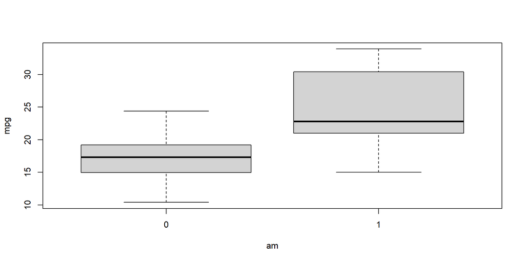

```r
boxplot(data = mtcars, mpg ~ am)
```

We can see that for cars with automatic transmission (am = 0), mpg is generally lower then for cars with manual transmission (am = 1), since their mean is lower. The distribution of mpg in automatic cars is more or less symmetric, while for manual transmission it is right skewed.

Reformat am as factor:

```r
mtcars <- mtcars %>% mutate(am = as.factor(am))
```

How many cars are there per group?

```r
table(mtcars$am)
```

```
##
##  0  1
## 19 13
```

Fit a linear regression model:

```r
slr1 <- lm(data = mtcars, mpg ~ am)
summary(slr1)
```

```
##
## Call:
## lm(formula = mpg ~ am, data = mtcars)
##
## Residuals:
##     Min      1Q  Median      3Q     Max
## -9.3923 -3.0923 -0.2974  3.2439  9.5077
##
## Coefficients:
##             Estimate Std. Error t value Pr(>|t|)
## (Intercept)   17.147      1.125  15.247 1.13e-15 ***
## am1            7.245      1.764   4.106 0.000285 ***
## ---
## Signif. codes:  0 '***' 0.001 '**' 0.01 '*' 0.05 '.' 0.1 ' ' 1
##
## Residual standard error: 4.902 on 30 degrees of freedom
## Multiple R-squared:  0.3598, Adjusted R-squared:  0.3385
## F-statistic: 16.86 on 1 and 30 DF,  p-value: 0.000285
```

There is a significant difference (alpha = 0.05) between the means calculated for each of the two groups (indicated by the significant p-vlaue for “am1” and because the 95% CIs for coefficients, that where fit for the two groups (automatic: 17.147 +/- 1.96x1.125; manual: 24.392 +/- 1.96x1.764) dont overlap.).  
The intercept is also statistically significant indicating that the calculated mean for am = 0 is a better predictor of the mpg than zero.

**Check Model Assumptions**

- Linearity

Since here the model just calculates the means of mpg for two different subsets, the linearity assumption is not an issue.

- Homoscedasticity

The same goes for homoscedasticity.

- Normality

We can look at a QQ plot to determine if the residuals are normally distributed:

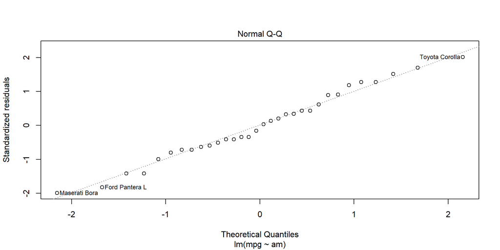

```r
plot(slr1, which = 2)
```

This seems to be more or less the case. We can also assess the same thing from the previously made boxplots, Since the residuals her are just the differences between the mean and the outcome value (mpg). Therefore if the values are more or less normally distributed around the mean, the same goes for the residuals.  
Here we have seen that for cars with manual transmission, this is not perfectly fulfilled.

#### 2.2.1.2 Categorical Predictor Variable

We will use cyl (Number of cylinders) as ordinal predictor. We cannot necessarily assume that the influence on mpg is as if it was a continuous parameter (e.g. the difference between 4 and 6 cylinders is the same as the difference between having 6 and 8 cylinders).

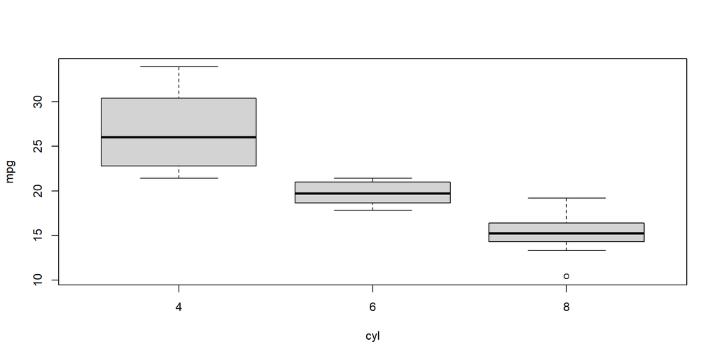

```r
boxplot(data = mtcars, mpg ~ cyl)
```

We see that the distributions for the three groups dont show much overlap. There is some right skew in the distributions of the 4 and 8 cylinder groups.

How many cars are there in each group:

```r
table(mtcars$cyl)
```

```
##
##  4  6  8
## 11  7 14
```

Reformat cyl as factor. Otherwise it would be interpreted by the lm() function as continuous:

```r
mtcars <- mtcars %>% mutate(cyl = as.factor(cyl))
```

Fit simple linear model:

```r
slr2 <- lm(data = mtcars, mpg ~ cyl)
summary(slr2)
```

```
##
## Call:
## lm(formula = mpg ~ cyl, data = mtcars)
##
## Residuals:
##     Min      1Q  Median      3Q     Max
## -5.2636 -1.8357  0.0286  1.3893  7.2364
##
## Coefficients:
##             Estimate Std. Error t value Pr(>|t|)
## (Intercept)  26.6636     0.9718  27.437  < 2e-16 ***
## cyl6         -6.9208     1.5583  -4.441 0.000119 ***
## cyl8        -11.5636     1.2986  -8.905 8.57e-10 ***
## ---
## Signif. codes:  0 '***' 0.001 '**' 0.01 '*' 0.05 '.' 0.1 ' ' 1
##
## Residual standard error: 3.223 on 29 degrees of freedom
## Multiple R-squared:  0.7325, Adjusted R-squared:  0.714
## F-statistic:  39.7 on 2 and 29 DF,  p-value: 4.979e-09
```

The significant p-values for cyl6 and cyl8 indicate that their means differ significantly from cyl = 4. The significant p-value of the intercept indicates that the mean for cyl = 4 differs significantly from zero.

We calculate the CI from a t-distribution of 32-3 degrees of freedom (sample size minus 1 for each estimated coefficient):

```r
#Intercept
slr2$coefficients[[1]] - qt(p = 0.975, df = 29)*0.9718
```

```
## [1] 24.67608
```

```r
slr2$coefficients[[1]] + qt(p = 0.975, df = 29)*0.9718
```

```
## [1] 28.65119
```

```r
#cyl6
slr2$coefficients[[2]] - qt(p = 0.975, df = 29)*1.5583
```

```
## [1] -10.10786
```

```r
slr2$coefficients[[2]] + qt(p = 0.975, df = 29)*1.5583
```

```
## [1] -3.733698
```

```r
#cyl8
slr2$coefficients[[3]] - qt(p = 0.975, df = 29)*1.2986
```

```
## [1] -14.21957
```

```r
slr2$coefficients[[3]] + qt(p = 0.975, df = 29)*1.2986
```

```
## [1] -8.907701
```

The adjusted R squared describes how much of the variation in the data is explained by the model adjusted for the number of predictor variables used. If there are only variables used, that add to the model it is close to the unadjusted R squared, which is the case here. The value we got here (0.714) is quite good and means that the model explains around 70 percent of the variability in the data.

**Check Model Assumptions**

Here again, since the model just calculates the means of mpg for different subsets, the linearity and homoscedasticity assumptions are not an issue.

- Normality

We can look at a QQ plot to determine if the residuals are normally distributed:

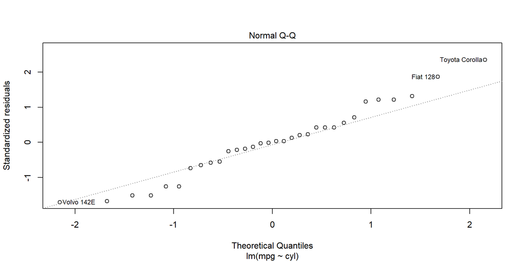

```r
plot(slr2, which = 2)
```

This is not perfect, but should be ok.

#### 2.2.1.3 Continuous Predictor Variable

We will now use qsec (1/4 mile time) to predict mpg.

Lets have a look at the distribution of the values

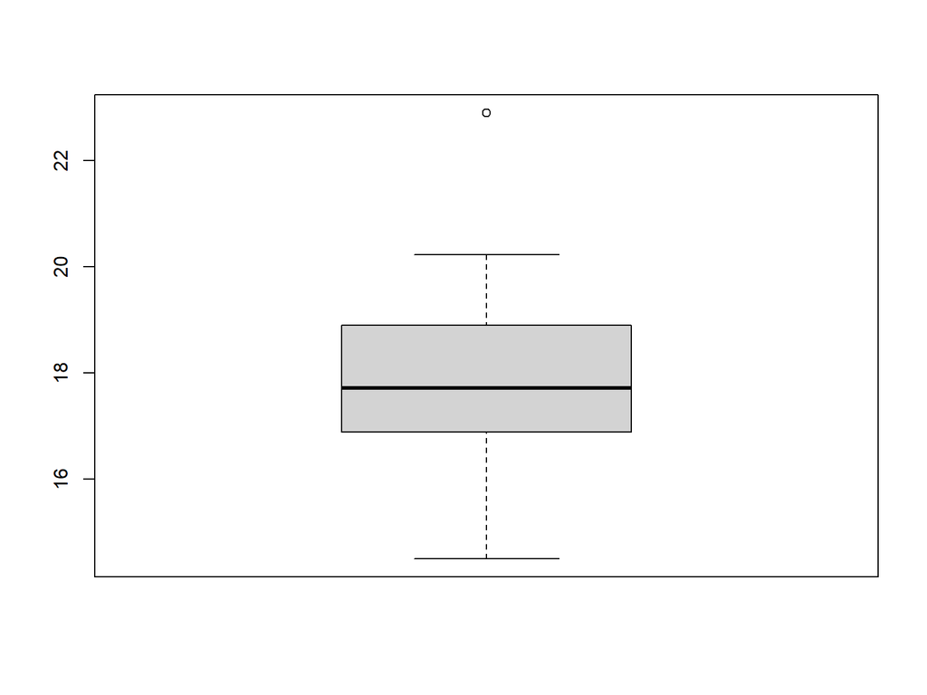

```r
boxplot(mtcars$qsec)
```

Lets produce a scatter plot of mpg vs qsec:

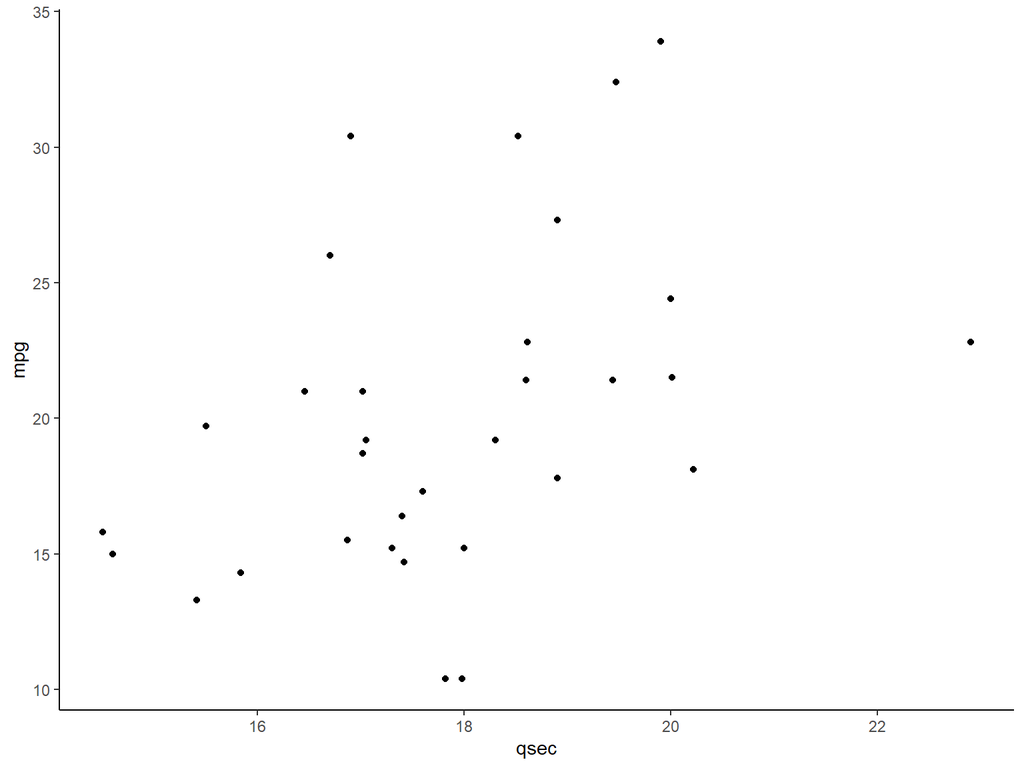

```r
ggplot(data = mtcars, aes(x = qsec, y = mpg)) +
  geom_point() +
  theme_classic()
```

There is a general increase of mpg with higher qsec times, but the association does not seem very strong. Nevertheless it makes sense to fit a linear model here.

Fit a linear regression model:

```r
slr3 <- lm(data = mtcars, mpg ~ qsec)
summary(slr3)
```

```
##
## Call:
## lm(formula = mpg ~ qsec, data = mtcars)
##
## Residuals:
##     Min      1Q  Median      3Q     Max
## -9.8760 -3.4539 -0.7203  2.2774 11.6491
##
## Coefficients:
##             Estimate Std. Error t value Pr(>|t|)
## (Intercept)  -5.1140    10.0295  -0.510   0.6139
## qsec          1.4121     0.5592   2.525   0.0171 *
## ---
## Signif. codes:  0 '***' 0.001 '**' 0.01 '*' 0.05 '.' 0.1 ' ' 1
##
## Residual standard error: 5.564 on 30 degrees of freedom
## Multiple R-squared:  0.1753, Adjusted R-squared:  0.1478
## F-statistic: 6.377 on 1 and 30 DF,  p-value: 0.01708
```

The adjusted R squared is quite low (0.15) meaning this model does not do a good job in explaining the variance in the data. This is consistent with the scatter plot above.  
The model shows a statistically significant association between qsec and mpg at an alpha of 0.05 (since the p-value, 0.0171 < 0.05). The intercept here is the theoretical mpg at the a theoretical qsec of zero. As this is impossible the coefficient is not meaningful here.  
The intercept is not statistically significant in this model. Since we dont have any values near the intercept this not a big problem, as it again only serves to fit the values in “further up” where the values of our sample are.  
It could however be a problem if we had some values near the intercept.

We can change the reference point for qsec from 0 to 14 by fitting a model for qsec-14 as predictor for mpg. This would mean that the intercept would become more meaningful, as qsec = 14 is a possible value. Then the intercept should hopefully be statistically significant.

```r
#valculate values qsec-14
mtcars_qsec14 <- mtcars %>% mutate(qsec_14 = qsec-14)
#fit model
slr4 <- lm(data = mtcars_qsec14, mpg ~ qsec_14)
summary(slr4)
```

```
##
## Call:
## lm(formula = mpg ~ qsec_14, data = mtcars_qsec14)
##
## Residuals:
##     Min      1Q  Median      3Q     Max
## -9.8760 -3.4539 -0.7203  2.2774 11.6491
##
## Coefficients:
##             Estimate Std. Error t value Pr(>|t|)
## (Intercept)  14.6557     2.3663   6.193 8.13e-07 ***
## qsec_14       1.4121     0.5592   2.525   0.0171 *
## ---
## Signif. codes:  0 '***' 0.001 '**' 0.01 '*' 0.05 '.' 0.1 ' ' 1
##
## Residual standard error: 5.564 on 30 degrees of freedom
## Multiple R-squared:  0.1753, Adjusted R-squared:  0.1478
## F-statistic: 6.377 on 1 and 30 DF,  p-value: 0.01708
```

The intercept changed and the coefficient is now statistically significant. This means, now we have more certainty that the true value for the intercept is not zero, which was not the case for the intercept in the previous model. This is also evident from the standard errors of the intercepts from the two models (ca 10 with the reference at 0 and ca. 2.3 with the reference at 14.)

Plot the model fit (with reference at 0)

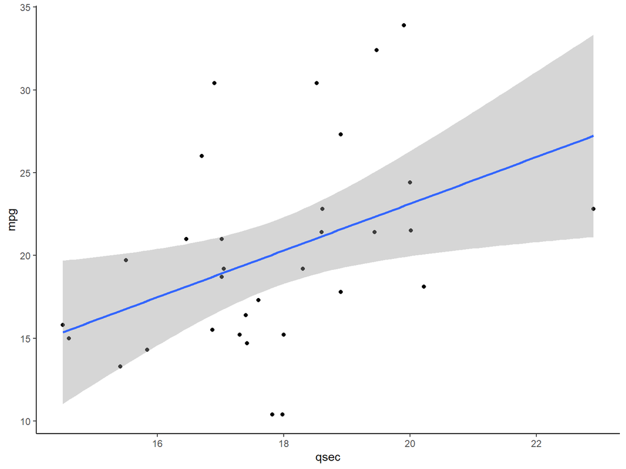

```r
ggplot(data = mtcars, aes(x = qsec, y = mpg)) +
  geom_point() +
  theme_classic() +
  geom_smooth(method='lm')
```

**Check Model Assumptions**

- Linearity

We had already looked at the scatter plot above. There is definitely not a strong linear relationship, but its good enough to fit a linear model.

- Homoscedasticity

To assess this we can look at a plot of the fitted value versus the sqrt of the absolute standardized residuals:

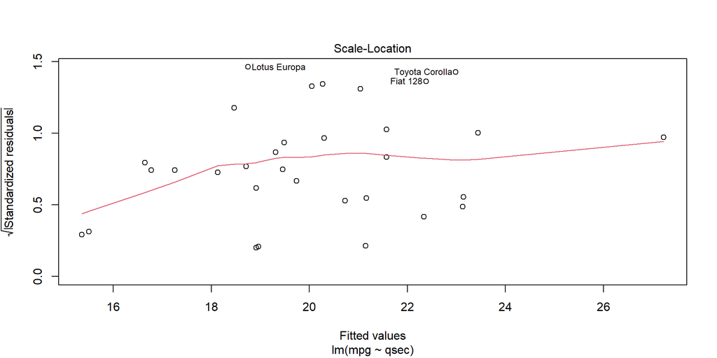

```r
plot(slr3, which = 3)
```

We see from the datapoints that there is not really a clear trend of increasing/decreasing variance on either side (higher, lower fitted values). Here the red line seems to indicate a slight trend from bottom left to top right, however this is only due to there being “very low / high” fitted values, which have a lot of influence of the fit of this line. We can consider this assumption fulfilled

- Extreme Values / Outliers

We can look at the Cooks distance to asses this:

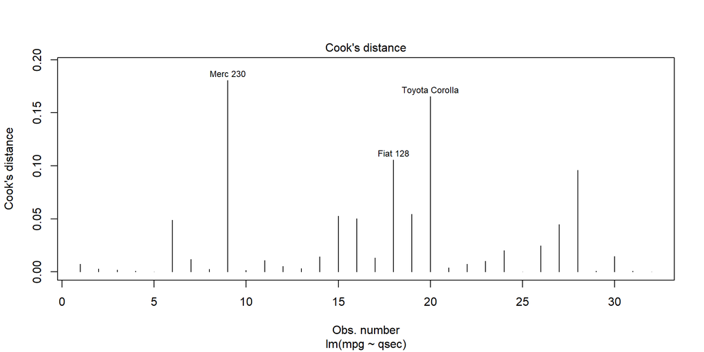

```r
plot(slr3, which = 4)
```

There are some observation (9, 20) that are quite a lot higher then the others. However I dont consider them extreme enough to pose a problem.

- Normality

We can look at a QQ plot to determine if the residuals are normally distributed:

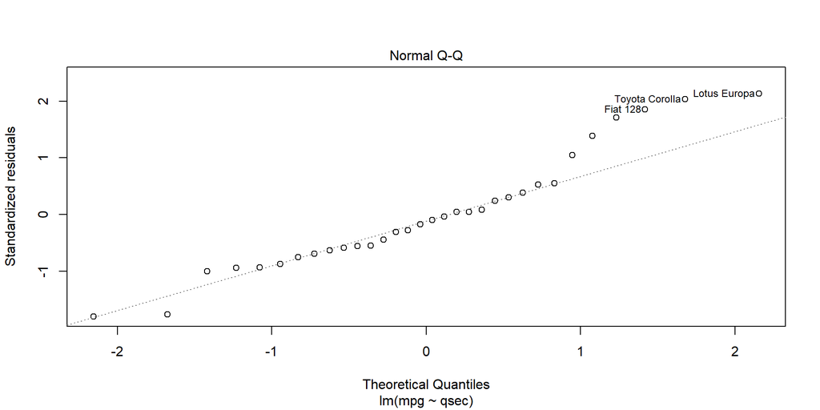

```r
plot(slr3, which = 2)
```

This is not perfect, but should be ok.

### 2.2.2 Multiple Linear Regression

#### 2.2.2.1 Binary + Categorical Predictor

We will use cyl (Number of cylinders) and am = Transmission (0 = automatic, 1 = manual) as predictors for mpg.

Create a contingency table:

```r
table(mtcars$cyl, mtcars$am)
```

```
##
##      0  1
##   4  3  8
##   6  4  3
##   8 12  2
```

There are some combinations that are quite rare (e.g. there are only two cars in the sample with 8 cylinders and manual transmission). This might influence the spread within these groups. For example it could be smaller if there are only two values in one group. Then the mean could be a quite accurate predictor in this group, while in bigger groups the spread might be larger.

Produce boxplots for the combinations between am and cyl:

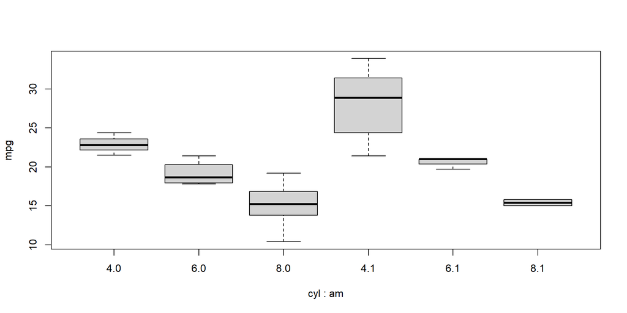

```r
boxplot(data = mtcars, mpg ~ cyl + am)
```

Since we dont have many samples we can also display single data points:

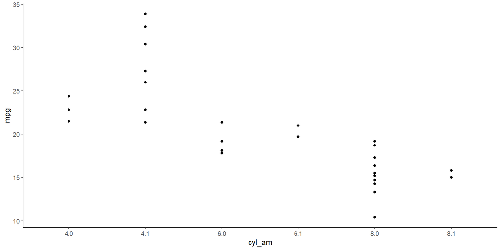

```r
mtcars %>% mutate(cyl_am = paste(cyl, am, sep = ".")) %>%
  ggplot(aes(x = cyl_am, y = mpg)) +
  geom_point() +
  theme_classic()
```

Here again we see that there is quite some overlap between the groups, especially between those with the same number of cylinders. We can also see that the number of cylinders is better at separating the data, then the transmission type, which barely contributes to the separation.

Fit a multiple linear regression model:

```r
mlr1 <- lm(data = mtcars, mpg ~ cyl + am)
summary(mlr1)
```

```
##
## Call:
## lm(formula = mpg ~ cyl + am, data = mtcars)
##
## Residuals:
##     Min      1Q  Median      3Q     Max
## -5.9618 -1.4971 -0.2057  1.8907  6.5382
##
## Coefficients:
##             Estimate Std. Error t value Pr(>|t|)
## (Intercept)   24.802      1.323  18.752  < 2e-16 ***
## cyl6          -6.156      1.536  -4.009 0.000411 ***
## cyl8         -10.068      1.452  -6.933 1.55e-07 ***
## am1            2.560      1.298   1.973 0.058457 .
## ---
## Signif. codes:  0 '***' 0.001 '**' 0.01 '*' 0.05 '.' 0.1 ' ' 1
##
## Residual standard error: 3.073 on 28 degrees of freedom
## Multiple R-squared:  0.7651, Adjusted R-squared:  0.7399
## F-statistic:  30.4 on 3 and 28 DF,  p-value: 5.959e-09
```

In this model the reference group are the cars with automatic transmission and 4 cylinders. Their mean mpg value is represented by the coefficient of the intercept. The other coefficients are the differences of the mean mpg of the respective groups to the reference group, adjusted by the other variable. E.g. the coefficient for am = 1 is the difference in mean mpg between automatic transmission and manual transmission, when the number of cylinders are the same.  
The differences between the reference and cyl = 6 as well as cyl = 8 adjusted for the transmission type are statistically significant at an alpha of 0.05. The difference between the transmission types adjusted for cylinder types are not statistically significant (it is close to it however). This (the am coefficient having a higher p-value then the cyl coefficients) is in line with the observations above from looking at the box plots of the groups.  
We can compare the adjusted R squared value to those of the models with only transmission type or number of cylinders we had previously fit:  
- Transmission type: Adj R suqared: 0.339  
- Nr. cylinders: Adj R suqared: 0.714  
So the combined model is only a little better then the model that used only the number of cylinders. Since the coefficient for transmission type in the model is not significantly different from zero, we cannot be certain, that the improvement was not due to chance.

**Check Model Assumptions**

- Homoscedasticity

To assess this we can look at a plot of the fitted value versus the sqrt of the standardized residuals:

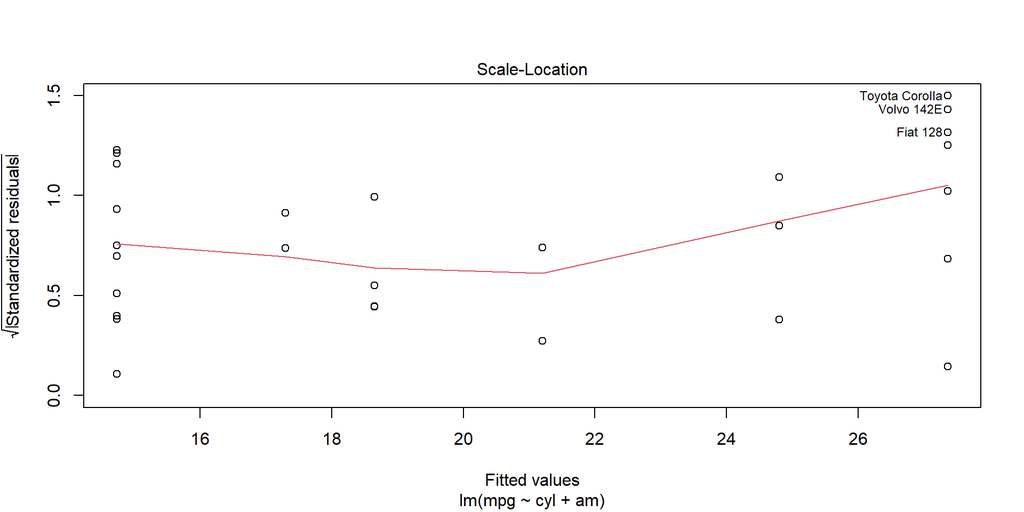

```r
plot(mlr1, which = 3)
```

We can consider this assumption fulfilled.

- Extreme Values / Outliers

We can look at the Cooks distance to asses this:

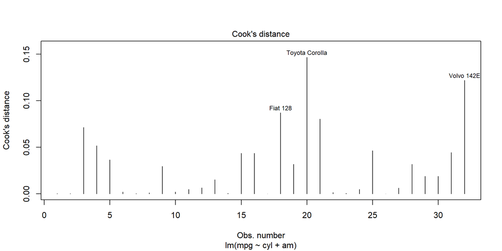

```r
plot(mlr1, which = 4)
```

This looks ok, We can consider this assumption fulfilled.

- Normality

We can look at a QQ plot to determine if the residuals are normally distributed:

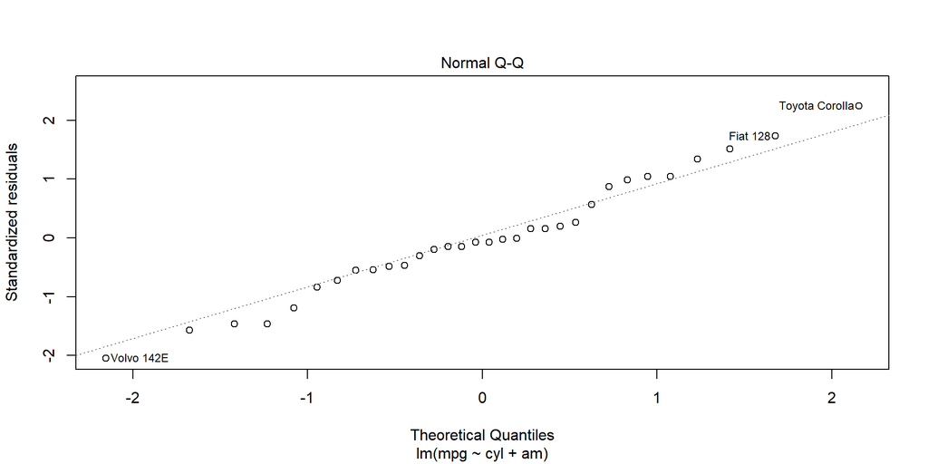

```r
plot(mlr1, which = 2)
```

This is not perfect, but should be ok.